# host_blood analysis

This notebook assess mosquito blood meal sources

Data description

An experiment was conducted in Tulizamoyo to to assess the proportion of two Anopheles mosquito Species: An. funestus and An. arabiensis (species), blood feeding on vertebrates (host_blood). The experiment was done in a field setting, and mosquitoes were collected in different houses (hh_id), using different traps (trap_method), indoors and outdoors (position). PCR targeting cytocrome b was performed on the samples collected, and the number of amplified samples were recorded (count).

Key question: What type of host do anopheles mosquitoes prefer to feed on, when the host availability is almost 50/50?

```r
rm(list = ls())
# list.files()
```

Load all required packages

```r
library(lme4, warn.conflicts = FALSE) # for generalized linear mixed effect models
library(MASS, warn.conflicts = FALSE) # for generalized models
suppressWarnings(library(tidyverse, warn.conflicts = FALSE)) # for data cleaning and manipulation
library(data.table, v) # import data table package to factor Xticks
library(ggplot2, warn.conflicts = FALSE) # for plotting
library(effects, warn.conflicts = FALSE)
library(ggeffects, warn.conflicts = FALSE)
library(sjPlot, warn.conflicts = FALSE)
```

load data

```r
# setwd("C:/Mannu/Projects/Mannu Phd/GLM_metadata")
metadata_df <- read.csv("C:/Mannu/Projects/Mannu Phd/GLM_metadata/_blood_meal_metadata_final.csv")

# factor house hold id column
metadata_df[,'hh_id'] <- as.factor(metadata_df[,'hh_id'])

# drop unused column
metadata_df <- select(metadata_df, -X)

# first print to the console all of the unique values you will need to recode)
print(distinct(metadata_df, host_blood))
```

| host_blood |
| --- |
| Bovine |
| Human |
| Dog |
| Human_cow |
| Human_dog |
| Cow_dog |

```r
# view data
glimpse(metadata_df)
```

```
Rows: 88
Columns: 6
$ species     <chr> "arabiensis", "arabiensis", "arabiensis", "arabiensis", "arabiensis", "arabiensis", "arabiens…
$ hh_id       <fct> 1, 1, 1, 1, 1, 1, 2, 2, 2, 2, 2, 3, 3, 3, 4, 4, 4, 4, 4, 4, 5, 5, 5, 5, 5, 5, 5, 1, 1, 1, 1, …
$ position    <chr> "indoor", "indoor", "indoor", "indoor", "outdoor", "outdoor", "indoor", "indoor", "indoor", "…
$ trap_method <chr> "CDC", "CDC", "PRK", "RBK", "PRK", "RBK", "CDC", "PRK", "RBK", "PRK", "RBK", "CDC", "RBK", "R…
$ host_blood  <chr> "Bovine", "Human", "Bovine", "Bovine", "Bovine", "Bovine", "Bovine", "Bovine", "Bovine", "Bov…
$ count       <int> 4, 1, 14, 1, 1, 55, 6, 4, 3, 2, 22, 1, 1, 34, 2, 3, 1, 3, 40, 1, 4, 3, 1, 4, 2, 44, 2, 8, 1, …
```

Recode all cow written factors as bovine

```r
metadata_df$host_blood <- recode(metadata_df$host_blood,
                                      Human_cow = "Human_bovine",
                                      Cow_dog = "Bovine_dog")
metadata_df$host_blood <- factor(metadata_df$host_blood, levels = c("Human", "Bovine", "Dog",
                                                                    "Human_bovine", "Human_dog", "Bovine_dog"))


print(distinct(metadata_df, host_blood))
```

| host_blood |
| --- |
| Bovine |
| Human |
| Dog |
| Human_bovine |
| Human_dog |
| Bovine_dog |

```r
NA
```

Exploring the data and visualizing the data

```r
# table() is a useful function for understanding the study design
# that produced the data set

print(table(metadata_df$host_blood))
```

```
       Human       Bovine          Dog Human_bovine    Human_dog   Bovine_dog
          20           40           13            9            3            3
```

```r
print(table(metadata_df$species))
```

```
arabiensis   funestus
        27         61
```

```r
# # mosquito species blood-fed on vertebrate

table(metadata_df$host_blood, metadata_df$species)
```

```
               arabiensis funestus
  Human                 2       18
  Bovine               23       17
  Dog                   2       11
  Human_bovine          0        9
  Human_dog             0        3
  Bovine_dog            0        3
```

```r
sumC <- tapply(metadata_df$count, list(metadata_df$host_blood,     metadata_df$species, metadata_df$position, metadata_df$trap_method), sum)
sumC
```

```
, , indoor, CDC

             arabiensis funestus
Human                 1      107
Bovine               17      330
Dog                  NA       41
Human_bovine         NA       14
Human_dog            NA        1
Bovine_dog           NA        3

, , outdoor, CDC

             arabiensis funestus
Human                NA       NA
Bovine               NA       NA
Dog                  NA       NA
Human_bovine         NA       NA
Human_dog            NA       NA
Bovine_dog           NA       NA

, , indoor, PRK

             arabiensis funestus
Human                NA       32
Bovine               24       92
Dog                   1        9
Human_bovine         NA        4
Human_dog            NA        3
Bovine_dog           NA       NA

, , outdoor, PRK

             arabiensis funestus
Human                NA        1
Bovine                8        1
Dog                  NA       NA
Human_bovine         NA       NA
Human_dog            NA       NA
Bovine_dog           NA       NA

, , indoor, RBK

             arabiensis funestus
Human                NA        6
Bovine               10       24
Dog                  NA        5
Human_bovine         NA       NA
Human_dog            NA       NA
Bovine_dog           NA        1

, , outdoor, RBK

             arabiensis funestus
Human                 1       21
Bovine              195      137
Dog                   2       10
Human_bovine         NA        8
Human_dog            NA        1
Bovine_dog           NA        1
```

```r
meanC <- tapply(metadata_df$count, list(metadata_df$host_blood, metadata_df$species, metadata_df$position), mean)
meanC
```

```
, , indoor

             arabiensis  funestus
Human          1.000000 12.083333
Bovine         3.642857 40.545455
Dog            1.000000  6.111111
Human_bovine         NA  3.600000
Human_dog            NA  2.000000
Bovine_dog           NA  2.000000

, , outdoor

             arabiensis  funestus
Human           1.00000  3.666667
Bovine         22.55556 23.000000
Dog             2.00000  5.000000
Human_bovine         NA  2.000000
Human_dog            NA  1.000000
Bovine_dog           NA  1.000000
```

Explanatory Plotting

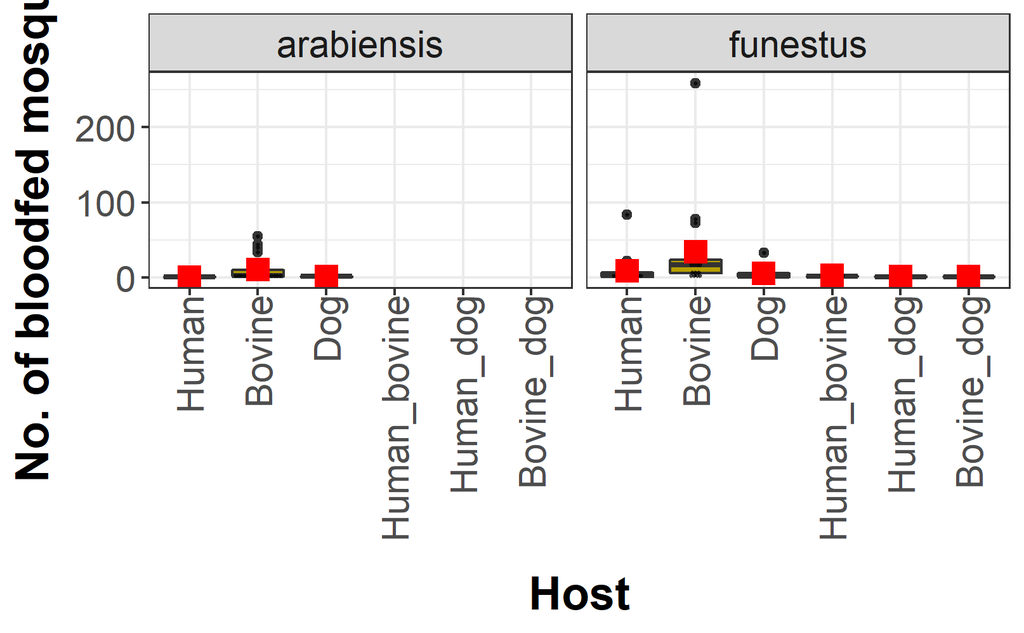

```r
ggplot(metadata_df, aes(x = host_blood, y = count)) +
  geom_boxplot(aes(fill = host_blood)) + # distinguish mosquito species by color
  geom_dotplot(binaxis="y", binwidth=4, stackdir="center", fill=1, alpha = 0.5) + # plot row data
  stat_summary(fun = mean, colour = "red", geom = "point", # add mean summary to the plot
  shape = 15, size = 4, show.legend = FALSE) + # estimate mean of the raw data
  facet_wrap(~ species) + # divide the data by Host to make two plot for host
  theme_bw() +
  ylab(expression(bold("No. of bloodfed mosquitoes"))) + # name y label
  xlab(expression(bold("Host"))) + # name X label
  theme(text = element_text(size = 18), # adjust font size
        legend.position = "none",
        axis.text.x = element_text(margin = margin(t = 0, r = 0, b = 13, l = 0), angle = 90, vjust = 0.5, hjust = 1)) # create space between
```

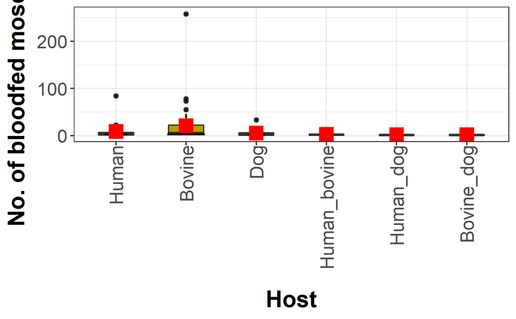

```r
ggplot(metadata_df, aes(x = host_blood, y = count, fill = host_blood)) + # distinguish host by color
  geom_boxplot(width = 0.5) +
  geom_dotplot(binaxis="y", binwidth=4, stackdir="center", fill=1, alpha = 0.5) + # plot row data
  stat_summary(fun = mean, colour = "red", geom = "point",
               shape = 15, size = 5,show.legend = FALSE) + # add mean summary
  theme_bw() +
  ylab(expression(bold("No. of bloodfed mosquitoes"))) +
  xlab(expression(bold("Host"))) +
  theme(text = element_text(size = 18), # adjust plot font size
        legend.position = "none",
        axis.text.x = element_text(margin = margin(t = 0, r = 0, b = 13, l = 0), angle = 90, vjust = 0.5, hjust = 1))
```

```r
NA
NA
```

*Model Fitting*

House hold Id will be treated as the random effects because we aren’t interested in generalizing their effects beyond the experiment.

The response variable count (no. of mosquitoes blood fed on a particular host), is modeled against the explanatory variables:

1. Host (different vertebrate which mosquito blooed-fed) - a factor with six levels
2. Position (indoor/outdoor collection) - a factor with two levels
3. Species (An. funestus/An. arabiensis) - a factor with two levels

*Null hypothesis*

N0: Anopheles mosquitoes prefer to bite humans than other vertebrate.

Since our response variable is a count, then Poisson GLMM will be a suitable model structure.

We will to fit a number of different models from complicated to simple, and likelihood ration test to test the importance of each variable in the model

```r
model1 <- glmer(count ~ host_blood + species + position + (1|hh_id), family = poisson, data = metadata_df)
summary(model1)
```

```
Generalized linear mixed model fit by maximum likelihood (Laplace Approximation) ['glmerMod']
 Family: poisson  ( log )
Formula: count ~ host_blood + species + position + (1 | hh_id)
   Data: metadata_df

     AIC      BIC   logLik deviance df.resid
  1490.3   1512.6   -736.1   1472.3       79

Scaled residuals:
    Min      1Q  Median      3Q     Max
-6.7653 -1.8366 -0.7766  0.5180 20.0175

Random effects:
 Groups Name        Variance Std.Dev.
 hh_id  (Intercept) 0.4471   0.6686
Number of obs: 88, groups:  hh_id, 5

Fixed effects:
                       Estimate Std. Error z value Pr(>|z|)
(Intercept)             0.71951    0.31934   2.253   0.0243 *
host_bloodBovine        1.29394    0.08681  14.906  < 2e-16 ***
host_bloodDog          -0.77903    0.14451  -5.391 7.01e-08 ***
host_bloodHuman_bovine -1.38517    0.21101  -6.564 5.22e-11 ***
host_bloodHuman_dog    -2.40923    0.45421  -5.304 1.13e-07 ***
host_bloodBovine_dog   -2.70033    0.45440  -5.943 2.81e-09 ***
speciesfunestus         1.13535    0.07394  15.354  < 2e-16 ***
positionoutdoor         0.10798    0.06385   1.691   0.0908 .
---
Signif. codes:  0 ‘***’ 0.001 ‘**’ 0.01 ‘*’ 0.05 ‘.’ 0.1 ‘ ’ 1

Correlation of Fixed Effects:
             (Intr) hst_bB hst_bD hst_bldHmn_b hst_bldHmn_d hst_B_ spcsfn
host_bldBvn  -0.266
host_blodDg  -0.136  0.487
hst_bldHmn_b -0.082  0.324  0.199
hst_bldHmn_d -0.035  0.150  0.094  0.065
hst_bldBvn_  -0.035  0.151  0.095  0.065        0.032
specisfnsts  -0.233  0.236  0.052 -0.006       -0.004       -0.003
positiontdr  -0.090 -0.003  0.018 -0.028       -0.025       -0.010  0.089
```

```r
# RR <- exp(coef(summary(model1))[,1])
# lower <- exp(coef(summary(model1))[,1] + qnorm(.025)*coef(summary(a1))[,2])
# upper <- exp(coef(summary(model1))[,1] + qnorm(.975)*coef(summary(a1))[,2])
# users_indoors = cbind(RR, lower, upper, pvalue=coef(summary(model1))[,4])
```

function to estimate and test over dispersion

from https://bbolker.github.io/mixedmodels-misc/glmmFAQ.html

```r
# Checking for over dispersion

overdisp_fun <- function(model) {
  rdf <- df.residual(model)
  rp <- residuals(model,type="pearson")
  Pearson.chisq <- sum(rp^2)
  prat <- Pearson.chisq/rdf
  pval <- pchisq(Pearson.chisq, df = rdf, lower.tail = FALSE)
  c(chisq = Pearson.chisq, ratio = prat, rdf = rdf, p = pval)
}
# This can also be done using overdisp.glmer() function in RVAideMemoire package.
# library(RVAideMemoire)
# overdisp.glmer(model3)

# but for now, let's use the function we have just created.
# Null hypothesis: There is no overdispersion in model 1

overdisp_fun(model1)
```

```
        chisq         ratio           rdf             p
 1.631634e+03  2.065359e+01  7.900000e+01 1.994816e-288
```

We can consider refit the model using a negative binomial GLMM (zero inflated model to account for over dispersion)

```r
model2 <- glmer.nb(count ~ host_blood + species + position + (1|hh_id), data = metadata_df)
summary(model2)
```

```
Generalized linear mixed model fit by maximum likelihood (Laplace Approximation) ['glmerMod']
 Family: Negative Binomial(1.1101)  ( log )
Formula: count ~ host_blood + species + position + (1 | hh_id)
   Data: metadata_df

     AIC      BIC   logLik deviance df.resid
   566.5    591.3   -273.3    546.5       78

Scaled residuals:
    Min      1Q  Median      3Q     Max
-0.9896 -0.6760 -0.3456  0.2199  5.0030

Random effects:
 Groups Name        Variance Std.Dev.
 hh_id  (Intercept) 0.3648   0.604
Number of obs: 88, groups:  hh_id, 5

Fixed effects:
                       Estimate Std. Error z value Pr(>|z|)
(Intercept)              0.7656     0.4853   1.577  0.11470
host_bloodBovine         1.3617     0.3256   4.182 2.89e-05 ***
host_bloodDog           -0.6360     0.3842  -1.656  0.09778 .
host_bloodHuman_bovine  -1.0615     0.4572  -2.322  0.02025 *
host_bloodHuman_dog     -1.9986     0.7844  -2.548  0.01084 *
host_bloodBovine_dog    -2.3363     0.7648  -3.055  0.00225 **
speciesfunestus          0.8818     0.3337   2.643  0.00823 **
positionoutdoor          0.3664     0.2682   1.366  0.17189
---
Signif. codes:  0 ‘***’ 0.001 ‘**’ 0.01 ‘*’ 0.05 ‘.’ 0.1 ‘ ’ 1

Correlation of Fixed Effects:
             (Intr) hst_bB hst_bD hst_bldHmn_b hst_bldHmn_d hst_B_ spcsfn
host_bldBvn  -0.610
host_blodDg  -0.321  0.445
hst_bldHmn_b -0.197  0.361  0.309
hst_bldHmn_d -0.127  0.204  0.196  0.153
hst_bldBvn_  -0.128  0.212  0.211  0.158        0.116
specisfnsts  -0.655  0.421  0.066 -0.057        0.006        0.019
positiontdr  -0.332 -0.077  0.014 -0.112       -0.035       -0.057  0.329
```

```r
print(overdisp_fun(model2))
```

```
       chisq        ratio          rdf            p
1.129466e+02 1.448034e+00 7.800000e+01 5.943291e-03
```

Checking whether variables have effect on the model, we will use anova to compare the base model with the new model

Model 3: Null hypothesis: Host has no effect, drop host from the model

```r
model3.no.host <- glmer.nb(count ~ species + position + (1|hh_id), data = metadata_df)
summary(model3.no.host)
```

```
Generalized linear mixed model fit by maximum likelihood (Laplace Approximation) ['glmerMod']
 Family: Negative Binomial(0.6561)  ( log )
Formula: count ~ species + position + (1 | hh_id)
   Data: metadata_df

     AIC      BIC   logLik deviance df.resid
   606.8    619.2   -298.4    596.8       83

Scaled residuals:
    Min      1Q  Median      3Q     Max
-0.7754 -0.6428 -0.5471  0.0600  9.4866

Random effects:
 Groups Name        Variance Std.Dev.
 hh_id  (Intercept) 0.2888   0.5374
Number of obs: 88, groups:  hh_id, 5

Fixed effects:
                Estimate Std. Error z value Pr(>|z|)
(Intercept)      1.98264    0.41683   4.756 1.97e-06 ***
speciesfunestus  0.08824    0.36231   0.244    0.808
positionoutdoor  0.42998    0.33115   1.298    0.194
---
Signif. codes:  0 ‘***’ 0.001 ‘**’ 0.01 ‘*’ 0.05 ‘.’ 0.1 ‘ ’ 1

Correlation of Fixed Effects:
            (Intr) spcsfn
specisfnsts -0.669
positiontdr -0.547  0.396
```

```r
anova(model2, model3.no.host)
```

```
Data: metadata_df
Models:
model3.no.host: count ~ species + position + (1 | hh_id)
model2: count ~ host_blood + species + position + (1 | hh_id)
               npar    AIC    BIC  logLik deviance  Chisq Df Pr(>Chisq)
model3.no.host    5 606.84 619.22 -298.42   596.84
model2           10 566.50 591.28 -273.25   546.50 50.335  5  1.183e-09 ***
---
Signif. codes:  0 ‘***’ 0.001 ‘**’ 0.01 ‘*’ 0.05 ‘.’ 0.1 ‘ ’ 1
```

From anova, we reject the null hypothesis that host has no effect on the model. we accept the alternative hypothesis that host has effect given LRT: DF = 5, chisq = 50.3, p < 0.001

Model 4: Null hypothesis: species has no effect, drop species from the model

```r
model4.no.species <- glmer.nb(count ~ host_blood + position + (1|hh_id), data = metadata_df)
summary(model4.no.species)
```

```
Generalized linear mixed model fit by maximum likelihood (Laplace Approximation) ['glmerMod']
 Family: Negative Binomial(1.0346)  ( log )
Formula: count ~ host_blood + position + (1 | hh_id)
   Data: metadata_df

     AIC      BIC   logLik deviance df.resid
   571.4    593.7   -276.7    553.4       79

Scaled residuals:
    Min      1Q  Median      3Q     Max
-0.9721 -0.6574 -0.3231  0.3150  4.2921

Random effects:
 Groups Name        Variance Std.Dev.
 hh_id  (Intercept) 0.4519   0.6722
Number of obs: 88, groups:  hh_id, 5

Fixed effects:
                       Estimate Std. Error z value Pr(>|z|)
(Intercept)              1.6148     0.3941   4.097 4.18e-05 ***
host_bloodBovine         1.0468     0.3000   3.489 0.000485 ***
host_bloodDog           -0.6939     0.3969  -1.748 0.080403 .
host_bloodHuman_bovine  -0.9978     0.4721  -2.114 0.034554 *
host_bloodHuman_dog     -2.0118     0.8023  -2.507 0.012163 *
host_bloodBovine_dog    -2.3744     0.7814  -3.039 0.002375 **
positionoutdoor          0.1387     0.2586   0.536 0.591841
---
Signif. codes:  0 ‘***’ 0.001 ‘**’ 0.01 ‘*’ 0.05 ‘.’ 0.1 ‘ ’ 1

Correlation of Fixed Effects:
             (Intr) hst_bB hst_bD hst_bldHmn_b hst_bldHmn_d hst_B_
host_bldBvn  -0.470
host_blodDg  -0.356  0.472
hst_bldHmn_b -0.297  0.428  0.313
hst_bldHmn_d -0.159  0.233  0.199  0.155
hst_bldBvn_  -0.152  0.239  0.212  0.161        0.120
positiontdr  -0.165 -0.223  0.000 -0.103       -0.040       -0.068
```

```r
anova(model2, model4.no.species)
```

```
Data: metadata_df
Models:
model4.no.species: count ~ host_blood + position + (1 | hh_id)
model2: count ~ host_blood + species + position + (1 | hh_id)
                  npar    AIC    BIC  logLik deviance  Chisq Df Pr(>Chisq)
model4.no.species    9 571.35 593.65 -276.68   553.35
model2              10 566.50 591.28 -273.25   546.50 6.8524  1   0.008852 **
---
Signif. codes:  0 ‘***’ 0.001 ‘**’ 0.01 ‘*’ 0.05 ‘.’ 0.1 ‘ ’ 1
```

Model 5: Null hypothesis: position has no effect, drop position from the model

```r
model5.no.position <- glmer.nb(count ~ host_blood + species + (1|hh_id), data = metadata_df)
summary(model5.no.position)
```

```
Generalized linear mixed model fit by maximum likelihood (Laplace Approximation) ['glmerMod']
 Family: Negative Binomial(1.081)  ( log )
Formula: count ~ host_blood + species + (1 | hh_id)
   Data: metadata_df

     AIC      BIC   logLik deviance df.resid
   566.4    588.7   -274.2    548.4       79

Scaled residuals:
    Min      1Q  Median      3Q     Max
-0.9621 -0.6902 -0.3707  0.1977  5.6130

Random effects:
 Groups Name        Variance Std.Dev.
 hh_id  (Intercept) 0.3401   0.5831
Number of obs: 88, groups:  hh_id, 5

Fixed effects:
                       Estimate Std. Error z value Pr(>|z|)
(Intercept)              0.9888     0.4553   2.172  0.02988 *
host_bloodBovine         1.4022     0.3283   4.271 1.95e-05 ***
host_bloodDog           -0.6425     0.3872  -1.659  0.09702 .
host_bloodHuman_bovine  -0.9917     0.4589  -2.161  0.03070 *
host_bloodHuman_dog     -1.9596     0.7806  -2.510  0.01206 *
host_bloodBovine_dog    -2.2748     0.7681  -2.962  0.00306 **
speciesfunestus          0.7354     0.3177   2.314  0.02065 *
---
Signif. codes:  0 ‘***’ 0.001 ‘**’ 0.01 ‘*’ 0.05 ‘.’ 0.1 ‘ ’ 1

Correlation of Fixed Effects:
             (Intr) hst_bB hst_bD hst_bldHmn_b hst_bldHmn_d hst_B_
host_bldBvn  -0.687
host_blodDg  -0.340  0.447
hst_bldHmn_b -0.253  0.355  0.312
hst_bldHmn_d -0.150  0.204  0.201  0.151
hst_bldBvn_  -0.158  0.209  0.215  0.152        0.117
specisfnsts  -0.623  0.475  0.067 -0.023        0.018        0.039
```

```r
anova(model2, model5.no.position)
```

```
Data: metadata_df
Models:
model5.no.position: count ~ host_blood + species + (1 | hh_id)
model2: count ~ host_blood + species + position + (1 | hh_id)
                   npar    AIC    BIC  logLik deviance  Chisq Df Pr(>Chisq)
model5.no.position    9 566.37 588.67 -274.19   548.37
model2               10 566.50 591.28 -273.25   546.50 1.8675  1     0.1718
```

From anova, we accept the null hypothesis that position has no effect on the model, given LRT: DF = 1, chisq = 1.9, p > 0.05

Refit the final model without position

```r
metadata_df_new = filter(metadata_df, host_blood != "Human_dog" & host_blood != "Bovine_dog")
final.model = glmer.nb(count ~ host_blood + species + (1|hh_id), data = metadata_df_new)
summary(final.model)
```

```
Generalized linear mixed model fit by maximum likelihood (Laplace Approximation) ['glmerMod']
 Family: Negative Binomial(1.0333)  ( log )
Formula: count ~ host_blood + species + (1 | hh_id)
   Data: metadata_df_new

     AIC      BIC   logLik deviance df.resid
   541.3    558.2   -263.7    527.3       75

Scaled residuals:
    Min      1Q  Median      3Q     Max
-0.9411 -0.6897 -0.4417  0.1384  5.4939

Random effects:
 Groups Name        Variance Std.Dev.
 hh_id  (Intercept) 0.3448   0.5872
Number of obs: 82, groups:  hh_id, 5

Fixed effects:
                       Estimate Std. Error z value Pr(>|z|)
(Intercept)              0.9874     0.4627   2.134   0.0328 *
host_bloodBovine         1.4040     0.3352   4.189 2.81e-05 ***
host_bloodDog           -0.6431     0.3946  -1.630   0.1031
host_bloodHuman_bovine  -0.9895     0.4667  -2.120   0.0340 *
speciesfunestus          0.7348     0.3248   2.262   0.0237 *
---
Signif. codes:  0 ‘***’ 0.001 ‘**’ 0.01 ‘*’ 0.05 ‘.’ 0.1 ‘ ’ 1

Correlation of Fixed Effects:
            (Intr) hst_bB hst_bD hst_H_
host_bldBvn -0.690
host_blodDg -0.341  0.447
hst_bldHmn_ -0.254  0.355  0.312
specisfnsts -0.626  0.476  0.067 -0.024
```

Inspect model

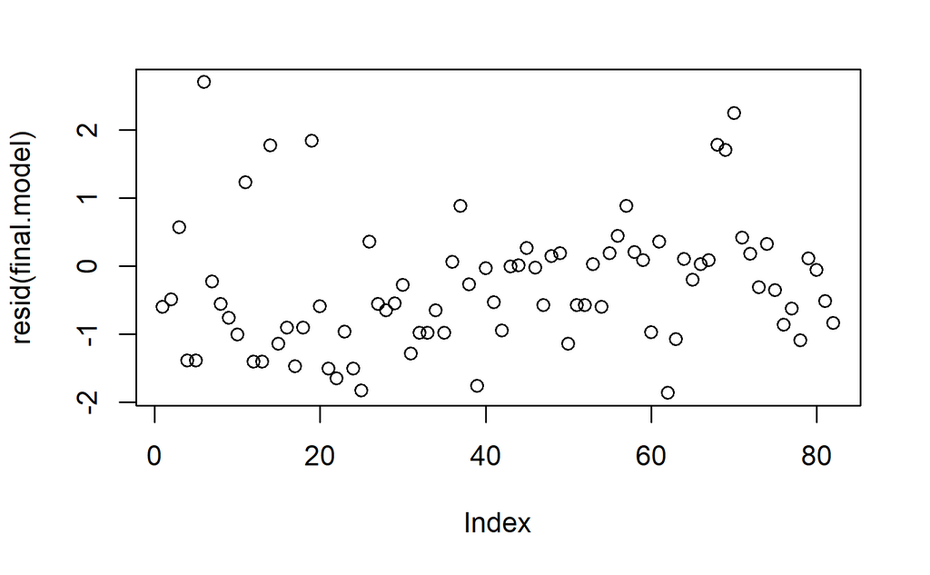

```r
plot(resid(final.model))
```

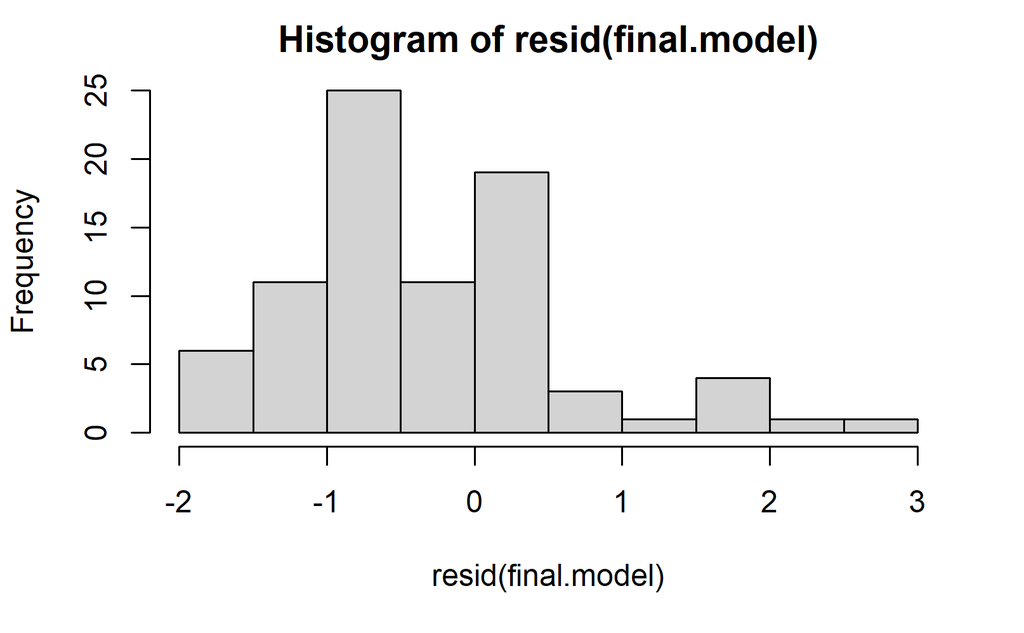

```r
hist(resid(final.model))
```

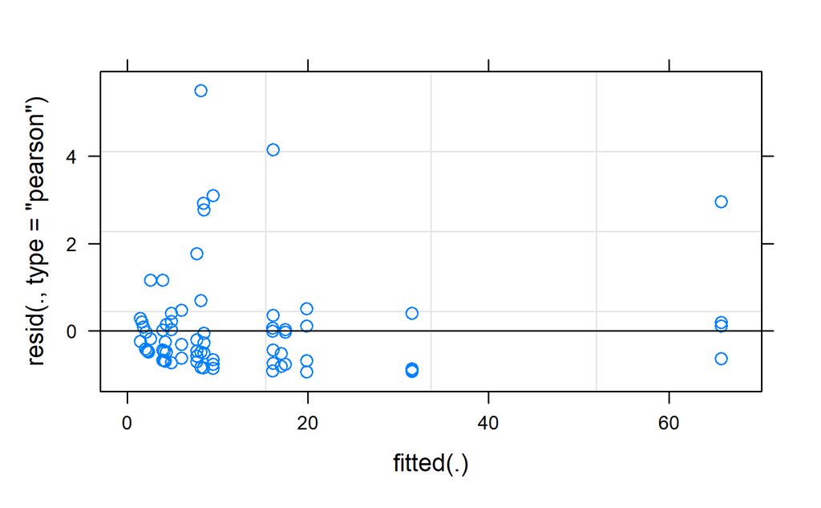

```r
plot(final.model)
```

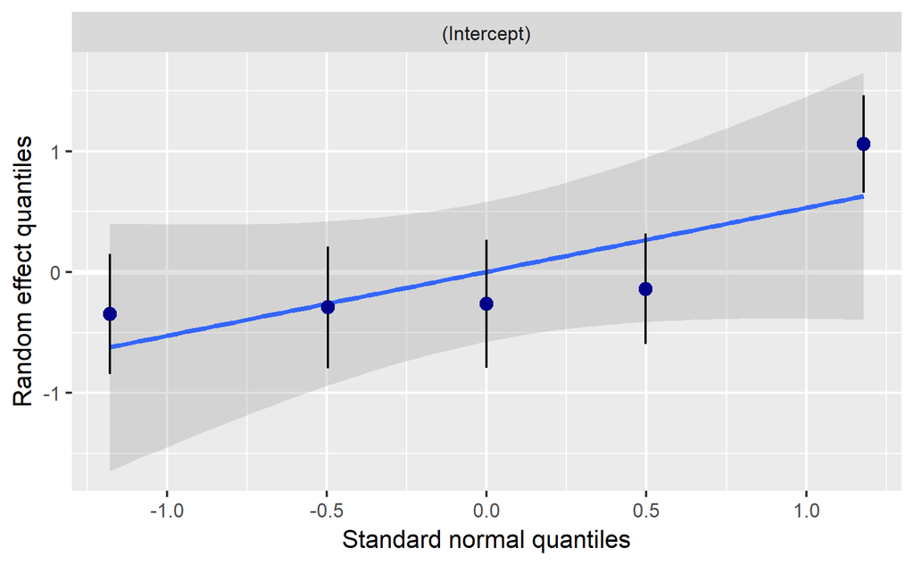

```r
# check the Q-Q plot, to evaluate the assumption of normality of
# the residuals.
plot_model(final.model, type = "diag")
```

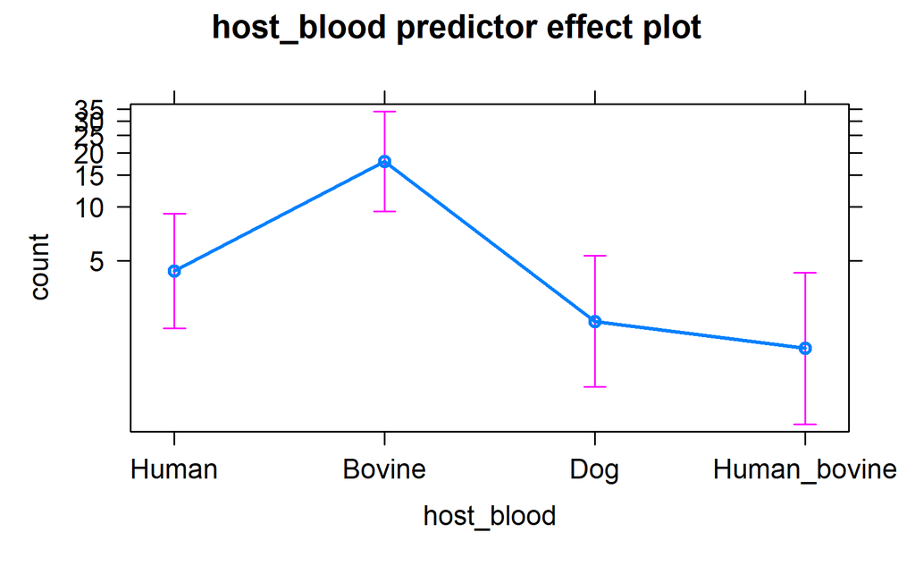

```r
# plot(allEffects(final.model)) # plot all model effects
plot(predictorEffects(final.model, ~ host_blood))
```

Exponentiation of the coefficients to get relative ratios, 95 CI values and report results of this final model

```r
RR <- exp(coef(summary(final.model))[,1])
lower <- exp(coef(summary(final.model))[,1] + qnorm(.025)*coef(summary(final.model))[,2])
upper <- exp(coef(summary(final.model))[,1] + qnorm(.970)*coef(summary(final.model))[,2])
cbind(RR, lower, upper, pvalue = coef(summary(final.model))[,4])
```

[output not shown]

Plotting figures from the model estimates

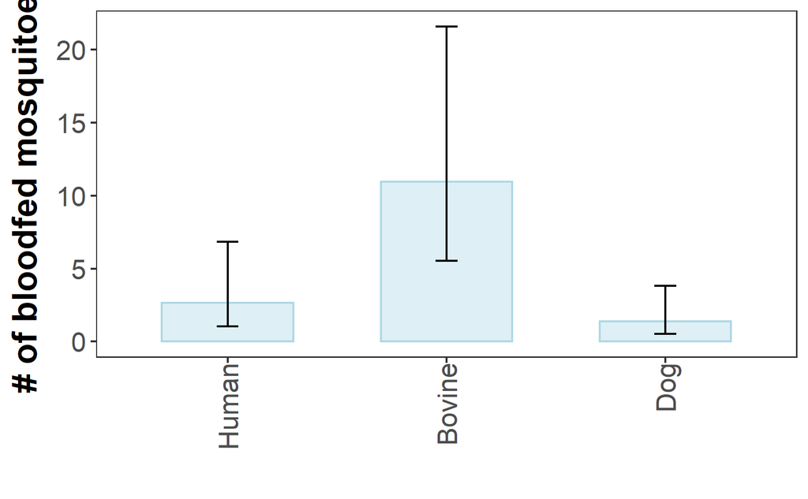

```r
df_hosts <- ggpredict(final.model, terms = c("host_blood"), ci.lvl = 0.95)

ggplot(df_hosts, aes(x = x, y = predicted)) +
  # scale_fill_manual(values = c("gray60")) +
  geom_bar(fill = "lightblue", color = "lightblue", alpha = .4,  stat = "identity", width = 0.6) +
  geom_errorbar(aes(ymin = conf.low, ymax = conf.high), width = 0.1) +
  theme_bw() +
  ylab(expression(bold("# of bloodfed mosquitoes"))) +
  xlab(expression(bold(" "))) +
  theme(text = element_text(size = 17), # adjust plot font size
        # aspect.ratio = 1/1,
        panel.grid.major = element_blank(),
        panel.grid.minor = element_blank(),
        legend.position = "none",
        axis.text.x = element_text(margin = margin(t = 0, r = 0, b = 13, l = 0), angle = 90, vjust = 0.5, hjust = 1))
```

```r
df_hosts
```

```
# Predicted counts of count

host_blood | Predicted |        95% CI
--------------------------------------
Human      |      2.67 | [1.04,  6.85]
Bovine     |     10.94 | [5.54, 21.60]
Dog        |      1.40 | [0.51,  3.84]

Adjusted for:
* species = arabiensis
*   hh_id = 0 (population-level)
```